# main

```python
# --------------------------------------
# Imports
# --------------------------------------

import matplotlib.pyplot as plt
import matplotlib.image as mpimg
import cv2
import os
from collections import deque
import numpy as np
from moviepy.editor import VideoFileClip
from os.path import join, basename

import numpy as np
import cv2
import matplotlib.pyplot as plt
import matplotlib.image as mpimg
import pickle
import pdb

import numpy as np
import cv2
import glob
import matplotlib.pyplot as plt
import pandas as pd

import os.path

import random
from sklearn.utils import shuffle
import pdb

import tensorflow as tf
from tensorflow.contrib.layers import flatten
from keras.preprocessing.image import ImageDataGenerator

# Imports for Jupyter
%matplotlib inline
```

```python
%%javascript
IPython.OutputArea.prototype._should_scroll = function(lines) {
    return false;
}
```

```python
# --------------------------------------
# Helper Functions
# --------------------------------------
def show_image(image, title="One Image", cmap=None, figsize=(14, 9)):
    f, ax1 = plt.subplots(1, 1, figsize=figsize)
    f.suptitle(title, fontsize=16)
    f.tight_layout()
    ax1.imshow(image, cmap=cmap)
    # ax1.set_title('First Image', fontsize=50)
    # ax2.imshow(image2, cmap=cmap2)
    # ax2.set_title('Second Image', fontsize=50)
    # plt.subplots_adjust(left=0., right=1, top=0.9, bottom=0.)
    plt.show()
```

## Load Data

```python
# Load pickled data
import pickle

# TODO: Fill this in based on where you saved the training and testing data

training_file = "./data/train.p"
validation_file= "./data/valid.p"
testing_file = "./data/test.p"

with open(training_file, mode='rb') as f:
    train = pickle.load(f)
with open(validation_file, mode='rb') as f:
    valid = pickle.load(f)
with open(testing_file, mode='rb') as f:
    test = pickle.load(f)

X_train, y_train = train['features'], train['labels']
X_valid, y_valid = valid['features'], valid['labels']
X_test, y_test = test['features'], test['labels']
```

## 1. Dataset Summary & Exploration

### 1.1 Basic Summary

```
Number of training examples = 34799
Number of testing examples = 12630
Number of validation examples = 4410
Image data shape = (32, 32, 3)
Number of classes = 43
sample_index 10590
```

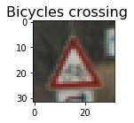

```python
n_train = X_train.shape[0]
n_valid = X_valid.shape[0]
n_test = X_test.shape[0]

sample_index = random.randint(0, n_train)
sample_image = X_train[sample_index, :, :, :]
image_shape = sample_image.shape

n_classes = np.unique(y_train).shape[0]

sign_names = pd.Series.from_csv("signnames.csv", header=0).to_dict()
sign_names_arr = []
for i in range(len(sign_names)):
    sign_names_arr.append(sign_names[i])


print("Number of training examples =", n_train)
print("Number of testing examples =", n_test)
print("Number of validation examples =", n_valid)
print("Image data shape =", image_shape)
print("Number of classes =", n_classes)

print("sample_index", sample_index)
show_image(sample_image, figsize=(2, 2), title=sign_names[y_train[sample_index]])
```

### 1.2 Visualization

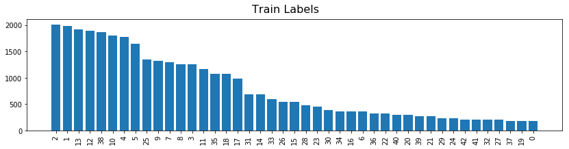

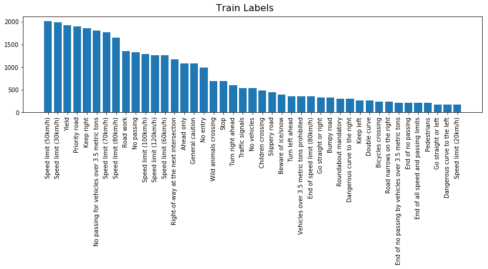

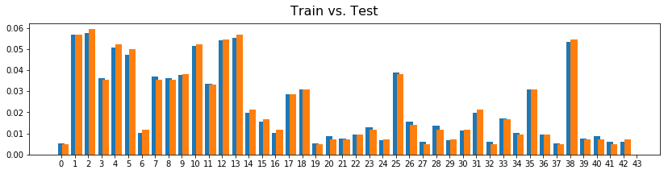

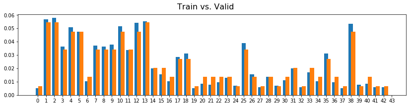

```python
counts = np.unique(y_train, return_counts=True)
counts_test = np.unique(y_test, return_counts=True)
counts_valid = np.unique(y_valid, return_counts=True)

xy = zip(counts[1].tolist(), counts[0].tolist(), sign_names_arr)
xy = sorted(xy)[::-1]
x = [str(a[1]) for a in xy]
z = [a[2] for a in xy]
y = [a[0] for a in xy]

# Histogram of labels
f = plt.figure(figsize=(14,3))
f.suptitle("Train Labels", fontsize=16)
plt.bar(x, y)
plt.xticks(rotation=90)
plt.show()

# Histogram In Text Labels
f = plt.figure(figsize=(14,3))
f.suptitle("Train Labels", fontsize=16)
plt.bar(z, y)
plt.xticks(rotation=90)
plt.show()

# Label Comparison
f = plt.figure(figsize=(14,3))
f.suptitle("Train vs. Test", fontsize=16)
plt.bar(counts[0], counts[1] / sum(counts[1]), width=.5)
plt.bar(counts_test[0] + 0.3, counts_test[1] / n_test, width=.5)
plt.xticks(np.arange(0, len(counts[0])+1, 1.0))
plt.show()

# Label Comparison
f = plt.figure(figsize=(14,3))
f.suptitle("Train vs. Valid", fontsize=16)
plt.bar(counts[0], counts[1] / sum(counts[1]), width=.5)
plt.bar(counts_valid[0] + 0.3, counts_valid[1] / n_valid, width=.5)
plt.xticks(np.arange(0, len(counts[0])+1, 1.0))
plt.show()
```

## Step 2: Design and Test a Model Architecture

### Preprocess

1. Shuffle the training data. This could mitigate the risk of the training getting stuck in a local minimum.
2. Each image is converted to YUV color space, and we only use the Y channel. This is an insight taken from LeCun's paper. While only selecting the Y channel seems to discard valuable information in the other two channels, it might reduce the simplicity of the decision making of the neural network. Take an extreme example, if somehow all the signs have the same shape and lines but engineereed to be very colorful, our human eyes would probably do better at telling the content of the signs by just looking at a gray scale version of the sign. The additional information from the other colors might just be a distraction.
3. I use histogram equalization to imporve contrast of the image. Improving contrast makes it easier to distinguish features. It is also a kind of normalization because images with bad constrasts will adjust more.

https://docs.opencv.org/3.1.0/d4/d1b/tutorial_histogram_equalization.html

1. I center and scale each pixel by its means and standard deviation. This should help the training. This allows SGD to converge faster.

https://becominghuman.ai/image-data-pre-processing-for-neural-networks-498289068258

```python
def shuffle_training_data(X, y):
    return shuffle(X, y)

def preprocess(X):
    new_X = []
    for img in X:
        img = np.expand_dims(cv2.cvtColor(img, cv2.COLOR_RGB2YUV)[:, :, 0], 2)  # Convert to YUV and keep only Y channel
        img = np.expand_dims(cv2.equalizeHist(np.uint8(img)), 2) # Improves the contrast

        new_X.append(img)

    X = np.array(new_X)
    X = np.float32(X)

    # Standardize
    X -= np.mean(X, axis=0)
    X /= (np.std(X, axis=0) + np.finfo('float32').eps)

    return X

X_train, y_train = shuffle_training_data(X_train, y_train)
X_train_ = preprocess(X_train)
X_test_ = preprocess(X_test)
X_valid_ = preprocess(X_valid)

# X_train_sample, y_train_sample = shuffle(X_train, y_train, n_samples=100)
# X_test_sample, y_test_sample = shuffle(X_test, y_test, n_samples=10)
# X_train_sample = preprocess(X_train_sample)
# X_test_sample = preprocess(X_test_sample)
```

### Model Architecture

Layer 1:

- Input shape is (32, 32, 1)
- Ouput shape is (32, 32, 64)
- The convolution filter is (3, 3) and has 64 channels
- Use Relu activation
- Max pool of a 2x2 square
- Drop out with a fixed probability

Layer 2:

- Ouput shape is (16, 16, 128)
- The convolution filter is (3, 3) and has 128 channels
- Use Relu activation
- Max pool of a 2x2 square
- Drop out with a fixed probability

Layer 3:

- A fully connected layer of the dropout outputs from layer 1 and layer 2
- Input size if 24576
- Output size is 64

Layer 4:

- The logit layer
- Output the probability of each class

```python
##########################
# Variables
##########################
EPOCHS = 27
BATCHES_PER_EPOCH = 5000
BATCHSIZE = 128
DROP_OUT_P = 0.5
DEBUG = False

# EPOCHS = 1
# BATCHES_PER_EPOCH = 10
# BATCHSIZE = 128
# DEBUG = True

print("-----------------------------")
print("data point per epoch: " + str(BATCHES_PER_EPOCH * BATCHSIZE) )
print("-----------------------------")

x = tf.placeholder(dtype=tf.float32, shape=(None, 32, 32, 1))
y = tf.placeholder(dtype=tf.int32, shape=None)
p = tf.placeholder(tf.float32)


def build_network(x, n_classes, p):
    depth1 = 64
    w = tf.Variable(tf.truncated_normal(shape=(3, 3, 1, depth1), mean=0, stddev=0.1))
    b = tf.Variable(tf.constant(value=0.1, shape=(depth1,)))
    conv1 = tf.nn.relu(tf.nn.conv2d(input=x, filter=w, strides=[1, 1, 1, 1], padding='SAME') + b)
    pool1 = tf.nn.max_pool(value=conv1, ksize=[1, 2, 2, 1], strides=[1, 2, 2, 1], padding='SAME')
    drop1 = tf.nn.dropout(pool1, keep_prob=p)

    depth2 = 128
    w = tf.Variable(tf.truncated_normal(shape=(3, 3, depth1, depth2), mean=0, stddev=0.1))
    b = tf.Variable(tf.constant(value=0.1, shape=(depth2,)))
    conv2 = tf.nn.relu(tf.nn.conv2d(input=drop1, filter=w, strides=[1, 1, 1, 1], padding='SAME') + b)
    pool2 = tf.nn.max_pool(value=conv2, ksize=[1, 2, 2, 1], strides=[1, 2, 2, 1], padding='SAME')
    drop2 = tf.nn.dropout(pool2, keep_prob=p)

    # layer 3
    fc0 = tf.concat([flatten(drop1), flatten(drop2)], 1)
    fc1_out = 64
    w = tf.Variable(tf.truncated_normal(shape=(fc0._shape[1].value, fc1_out), mean=0, stddev=0.1))
    b = tf.Variable(tf.constant(value=0.1, shape=(fc1_out,)))
    fc1 = tf.matmul(fc0, w) + b
    drop_fc1 = tf.nn.dropout(fc1, keep_prob=p)

    # layer 4
    fc2_out = n_classes
    w = tf.Variable(tf.truncated_normal(shape=(drop_fc1._shape[1].value, fc2_out), mean=0, stddev=0.1))
    b = tf.Variable(tf.constant(value=0.1, shape=(fc2_out,)))

    logits = tf.matmul(drop_fc1, w) + b

    return logits


def evaluate(X_data, y_data):

    num_examples = X_data.shape[0]
    total_accuracy = 0

    sess = tf.get_default_session()
    for offset in range(0, num_examples, BATCHSIZE):
        batch_x, batch_y = X_data[offset:offset+BATCHSIZE], y_data[offset:offset+BATCHSIZE]
        accuracy = sess.run(accuracy_operation, feed_dict={x: batch_x, y: batch_y, p: 1.0})
        total_accuracy += accuracy * len(batch_x)

    return total_accuracy / num_examples


data_gen = ImageDataGenerator(
    rotation_range=20.,
    zoom_range=0.1,
    shear_range=0.05,
    width_shift_range=0.07,
    height_shift_range=0.07
)


# Training pipeline
lr = 0.001
logits = build_network(x, n_classes, p)
cross_entropy = tf.nn.sparse_softmax_cross_entropy_with_logits(logits=logits, labels=y)
loss_function = tf.reduce_mean(cross_entropy)
optimizer = tf.train.AdamOptimizer(learning_rate=lr)
training_operation = optimizer.minimize(loss=loss_function)

# Metrics
correct_prediction = tf.equal(tf.argmax(logits, 1), tf.cast(y, tf.int64))
accuracy_operation = tf.reduce_mean(tf.cast(correct_prediction, tf.float32))
saver = tf.train.Saver()
```

```
-----------------------------
data point per epoch: 640000
-----------------------------
WARNING:tensorflow:Tensor._shape is private, use Tensor.shape instead. Tensor._shape will eventually be removed.
WARNING:tensorflow:Tensor._shape is private, use Tensor.shape instead. Tensor._shape will eventually be removed.
```

## Discussion

- I am using the Adam optimizer. I chose this because it is straight forward and has less parameters to tweak.
- Batchsize is 128. This might work better if it is higher, but I didn't think that it is critical so I didn't play around with that.
- I chose 5000 batches per epoch. I chose this mostly for a reasonable printed output. When I was tweaking the parameters, I was using lower batches per epoch so that I have more frequent insights into its evaluation. The key is that **EPOCH *BATCHES_PER_EPOCH* BATCHSIZE)** are sufficiently hihgh to ensure that the training gets close to the minimal losss state.
- I am training with 27 epochs.
- I am using a drop out rate of 0.5. This drop out probability is used in three different layers. There is no need for them to be the same, but it is simple to have just one parameter instead of mulitple.

Note: https://www.tensorflow.org/api_docs/python/tf/train/AdamOptimizer

### Train, Validate and Test the Model

A validation set can be used to assess how well the model is performing. A low accuracy on the training and validation sets imply underfitting. A high accuracy on the training set but low accuracy on the validation set implies overfitting.

```python
trainingX = X_train_
traningY = y_train

with tf.Session() as sess:
    sess.run(tf.global_variables_initializer())
    for epoch in range(EPOCHS):
        print(f'Epoch: {epoch}')

        batch_counter = 0
        for batch_x, batch_y in data_gen.flow(trainingX, traningY, batch_size=BATCHSIZE):
            batch_counter += 1
            r = sess.run(training_operation, feed_dict={x: batch_x, y: batch_y, p: DROP_OUT_P})

            if batch_counter == BATCHES_PER_EPOCH:
                break

            # DEBUG
            if (batch_counter % 100 == 0 and DEBUG):
                print(batch_counter)
                print(f"Epoch progress {batch_counter}: {(BATCHSIZE * batch_counter) / (BATCHES_PER_EPOCH * BATCHSIZE)}")

        # DEBUG
        train_accuracy = evaluate(trainingX, traningY)
        val_accuracy = evaluate(X_valid, y_valid)
        print(f'Train accuracy: {train_accuracy}')
        print(f'Validation accuracy: {val_accuracy}')

        # Save Model
        saver.save(sess, './data/lenet')
```

[output not shown]

[output cut: 26 more lines]

[output not shown]

## Discussion of Model and Training

- I found that adding drop outs layer substantially improve performance. Furthermore, having a relatively high dropout probability seems to work well.
- I found that initialization of the weight variables affect training quite a bit as well. I ended up using (mean=0, stddev=0.1), and found it much better than using all zeros or using something with higher variance away from mean zero.
- I found that the sizes of the kernel for the max pool and convolution do not affect performance much due to small changes. If we were to double their sizes, they start to severely affect performance.
- We could combined training and validation data to train the model for a final time after we have determine the model and hyperparameters. That would give the training even more data.
- We didn't do that because I am using my local computer to train, and it does not have access to GPU. The full training takes almost 12 hours to complete.

```python
with tf.Session() as sess:
    saver.restore(sess, './data/lenet')
    res = evaluate(X_test_, y_test)
    print('\n---------------------------')
    print(f'Test set accuracy: {res}')
```

```
INFO:tensorflow:Restoring parameters from ./data/lenet

---------------------------
Test set accuracy: 0.9308788599613066
```

## Step 3: Test a Model on New Images

#### Preview images

[figure not shown]

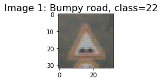

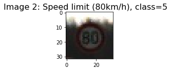

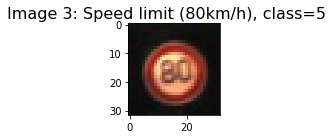

[figure not shown]

[figure not shown]

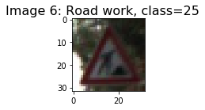

[figure not shown]

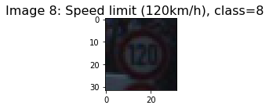

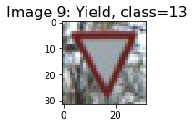

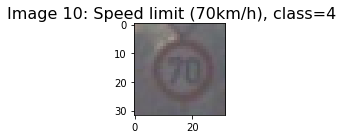

```python
filenames = []
for f in os.listdir('./data/images'):
    if f.startswith('image'):
        filenames.append(f)

filenames = filenames[:]
images = []
image_labels = []
image_label_names = []
for f in filenames:
    label_index = int(f.split('__')[-1].split('.')[0])
    label_name = sign_names[label_index]
    image = mpimg.imread(f'./data/images/{f}')
    images.append(image)
    image_labels.append(label_index)
    image_label_names.append(label_name)

# Plot
for i, f in enumerate(filenames):
    image = images[i]
    label_index = int(f.split('__')[-1].split('.')[0])
    label_name = sign_names[label_index]
    label_index_hat = pred_labels[i]
    label_name_hat = sign_names[label_index_hat]

    # Show image
    title = f'Image {i}: {label_name}, class={label_index}'
    show_image(image, figsize=(2, 2), title=title)
```

#### Testing Model

```
INFO:tensorflow:Restoring parameters from ./data/lenet


--------------
[False, True, True, True, True, True, True, True, True, True, True]
Model Accuracy: 0.9090909090909091
--------------
```

```
Expected=17, No entry | Prediced=40, Roundabout mandatory
```

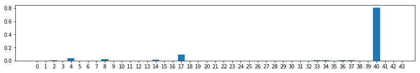

```
40, p=0.8038130402565002
17, p=0.0951382964849472
4, p=0.040403515100479126
8, p=0.02293882705271244
14, p=0.013789585791528225
------------------------
```

```
Expected=22, Bumpy road | Prediced=22, Bumpy road
```

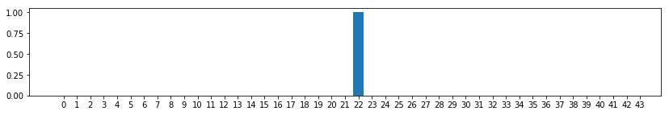

```
22, p=1.0
25, p=2.1588654475213076e-11
30, p=9.356440284818881e-15
18, p=7.845381787795203e-15
21, p=4.172153955325254e-15
------------------------
```

```
Expected=5, Speed limit (80km/h) | Prediced=5, Speed limit (80km/h)
```

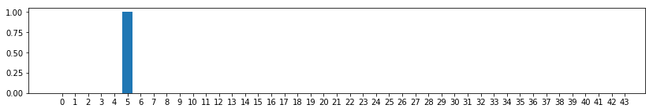

```
5, p=0.9985707998275757
3, p=0.0009190289420075715
7, p=0.00024603112251497805
2, p=0.00023791454441379756
8, p=2.515346568543464e-05
------------------------
```

```
Expected=5, Speed limit (80km/h) | Prediced=5, Speed limit (80km/h)
```

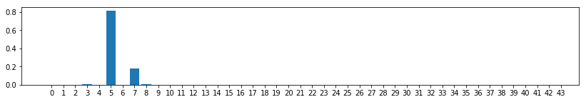

```
5, p=0.8120726943016052
7, p=0.175038143992424
3, p=0.007157397456467152
8, p=0.004934666212648153
2, p=0.0004222902934998274
------------------------
```

```
Expected=38, Keep right | Prediced=38, Keep right
```

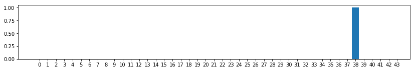

```
38, p=0.9982374906539917
2, p=0.001397549407556653
40, p=0.0003272644826211035
0, p=1.3742680494033266e-05
1, p=7.909999112598598e-06
------------------------
```

```
Expected=9, No passing | Prediced=9, No passing
```

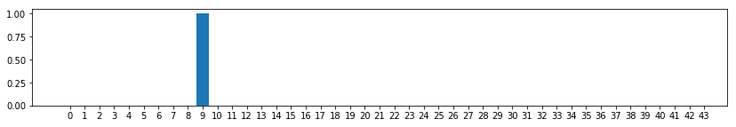

```
9, p=0.9999839067459106
10, p=9.591429261490703e-06
16, p=6.489625775429886e-06
2, p=8.615051450000522e-10
8, p=7.424344472539701e-10
------------------------
```

```
Expected=25, Road work | Prediced=25, Road work
```

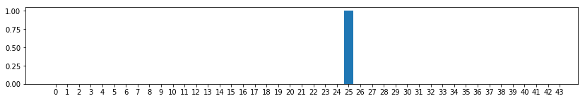

```
25, p=0.9999992847442627
2, p=2.218892234395753e-07
30, p=2.0389914823226718e-07
5, p=6.190478529788379e-08
23, p=3.315970786843536e-08
------------------------
```

```
Expected=13, Yield | Prediced=13, Yield
```

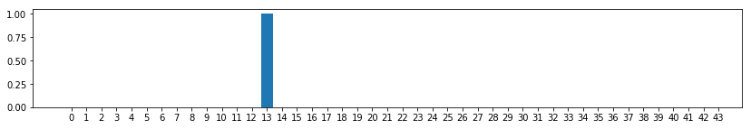

```
13, p=0.9999995231628418
7, p=2.651810007137101e-07
3, p=1.286123278987361e-07
8, p=1.1302319791184345e-07
5, p=4.8999034163443866e-08
------------------------
```

```
Expected=8, Speed limit (120km/h) | Prediced=8, Speed limit (120km/h)
```

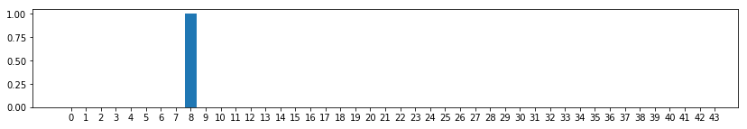

```
8, p=0.9998406171798706
7, p=5.70983174839057e-05
5, p=3.181238571414724e-05
4, p=2.8900278266519308e-05
0, p=1.798107950889971e-05
------------------------
```

```
Expected=13, Yield | Prediced=13, Yield
```

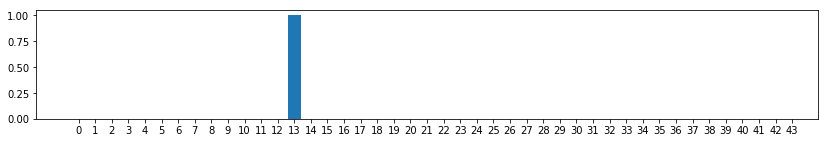

```
13, p=1.0
12, p=5.348143261585392e-09
15, p=3.661490381723365e-12
9, p=6.143038687326033e-14
14, p=2.0380058250268722e-14
------------------------
```

```
Expected=4, Speed limit (70km/h) | Prediced=4, Speed limit (70km/h)
```

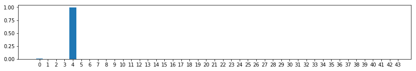

```
4, p=0.9920033812522888
0, p=0.005537418648600578
1, p=0.002385760424658656
2, p=4.341559542808682e-05
8, p=2.9889199140598066e-05
------------------------
```

```python
filenames = []
for f in os.listdir('./data/images'):
    if f.startswith('image'):
        filenames.append(f)

filenames = filenames[:]
images = []
image_labels = []
image_label_names = []
for f in filenames:
    label_index = int(f.split('__')[-1].split('.')[0])
    label_name = sign_names[label_index]
    image = mpimg.imread(f'./data/images/{f}')
    images.append(image)
    image_labels.append(label_index)
    image_label_names.append(label_name)

# Run the feedforward calculations
# images = np.array(images)
X_images = preprocess(images)
pred_bool = []
pred_labels = []
pred_label_names = []
K = 5
with tf.Session() as sess:
    saver.restore(sess, './data/lenet')
    outputs = sess.run(logits, feed_dict={x: X_images, p: 1})
    pred_labels = np.argmax(np.array(outputs), axis=1)
    top_k = sess.run(tf.nn.top_k(logits, k=K), feed_dict={x: X_images, p: 1})
    softmax_probs = sess.run(tf.nn.softmax(logits), feed_dict={x: X_images, p: 1})

# Calculate data
for i, f in enumerate(filenames):
    label_index = int(f.split('__')[-1].split('.')[0])
    label_index_hat = pred_labels[i]
    pred_bool.append(label_index == label_index_hat)

msg = f'Model Accuracy: {sum(pred_bool)/len(pred_bool)}'
print("\n\n--------------")
print(pred_bool)
print(msg)
print("--------------")
print("\n")

# Plot
for i, f in enumerate(filenames):
    image = images[i]
    label_index = int(f.split('__')[-1].split('.')[0])
    label_name = sign_names[label_index]
    label_index_hat = pred_labels[i]
    label_name_hat = sign_names[label_index_hat]

    # Show image
    show_image(image, figsize=(1.5, 1.5), title="")
    title = f'Expected={label_index}, {label_name} | Prediced={label_index_hat}, {label_name_hat}'
    print(title)

    # Plot probabilities
    f = plt.figure(figsize=(14, 2))
    plt.bar(np.arange(n_classes), softmax_probs[i])
    plt.xticks(np.arange(0, n_classes+1, 1.0))
    plt.show()

    # Print top choices and confidence level
    for k in range(K):
        choice = top_k[1][i][k]
        print(f'{choice}, p={softmax_probs[i][choice]}')
    print("------------------------\n")
```

### Discussion

-- The result on images found on the internet matches well with our performance test on the test set. The model predicted 90% of outside images correctly. It is about the the same as 93% in the test data set.

-- For the one image that it does not predict correctly, the probability distribution does indicate that the correct label would have been the second choice.

-- The distribution indicates that for those that are predicted correctly, we have very high confidence that they are correct. For most of the images, the softmax puts more than 95% of the probability on the correct label.